# Exposure and Fixed-Effects modelling

# Signal strength, all cause, DALY

Now to look at the equivalent for DALYs

```r
daly_rate_data_joined %>%
  produce_table(
    this_cause = "All causes",
    this_caption = "Signal strength of indicators on male and female age-standardised all-cause DALY rate trends")
```

Joining, by = “indicator_id”

| indicator_id | indicator | male_t | female_t | male_rank | female_rank | diff |
| --- | --- | --- | --- | --- | --- | --- |
| SP.URB.TOTL.FE.ZS | Urban population, female (% of total) | -21.71 | -24.90 | 1 | 1 | 0 |
| SP.URB.TOTL.MA.ZS | Urban population, male (% of total) | -21.12 | -21.90 | 2 | 2 | 0 |
| NY.GDP.PCAP.PP.CD | GDP per capita, PPP (current international $) | -17.93 | -17.15 | 3 | 3 | 0 |
| SE.ENR.PRIM.FM.ZS | School enrollment, primary (gross), gender parity index (GPI) | -11.70 | -14.84 | 4 | 4 | 0 |
| SE.ENR.PRSC.FM.ZS | School enrollment, primary and secondary (gross), gender parity index (GPI) | -10.17 | -13.38 | 5 | 5 | 0 |
| SE.ENR.TERT.FM.ZS | School enrollment, tertiary (gross), gender parity index (GPI) | -9.29 | -10.66 | 6 | 7 | -1 |
| SE.ENR.SECO.FM.ZS | School enrollment, secondary (gross), gender parity index (GPI) | -9.11 | -12.14 | 7 | 6 | 1 |
| SH.HIV.ARTC.MA.ZS | Access to anti-retroviral drugs, male (%) | -8.84 | -8.70 | 8 | 8 | 0 |
| SH.HIV.ARTC.FE.ZS | Access to anti-retroviral drugs, female (%) | -7.17 | -7.20 | 9 | 10 | -1 |
| SG.H2O.PRMS.HH.ZS | Households with water on the premises (%) | -6.30 | -7.83 | 10 | 9 | 1 |
| SG.H2O.TM30.HH.ZS | Households with water 30 minutes or longer away round trip (%) | 5.39 | 6.28 | 11 | 11 | 0 |
| SE.ADT.1524.LT.FM.ZS | Literacy rate, youth (ages 15-24), gender parity index (GPI) | -5.09 | -6.07 | 12 | 12 | 0 |
| UNDP.HDI.XD | Human development index (HDI) | -4.73 | -5.84 | 13 | 15 | -2 |
| SG.COK.LPGN.ZS | Main cooking fuel: LPG/natural gas/biogas (% of households) | -4.65 | -5.91 | 14 | 14 | 0 |
| SG.COK.WOOD.ZS | Main cooking fuel: wood (% of households) | 4.58 | 5.31 | 15 | 16 | -1 |
| SE.NED.HIAT.MA.ZS | Educational attainment, no schooling, population 25+ years, male (%) | 4.37 | 5.92 | 16 | 13 | 3 |
| SE.NED.HIAT.FE.ZS | Educational attainment, no schooling, population 25+ years, female (%) | 3.56 | 5.23 | 17 | 17 | 0 |
| SG.DMK.HLTH.HB.ZS | Decision maker about a woman’s own health care: mainly husband (% of women age 15-49) | 2.89 | 3.56 | 18 | 18 | 0 |
| SL.UEM.1524.FM.ZS | Ratio of female to male youth unemployment rate (% ages 15-24) (modeled ILO estimate) | -2.85 | -2.07 | 19 | 23 | -4 |
| SG.DMK.HLTH.FN.ZS | Women participating in own health care decisions (% of women age 15-49) | -2.43 | -3.05 | 20 | 19 | 1 |
| 5.51.01.07.gender | Gender equality in education | -2.10 | -2.55 | 21 | 21 | 0 |
| SG.DMK.FOOD.FN.ZS | Women participating in decision of what food to cook daily (% of women age 15-49) | -1.95 | -2.56 | 22 | 20 | 2 |
| SG.COK.HOUS.ZS | Location of cooking: inside the house (% of households) | -1.92 | -2.31 | 23 | 22 | 1 |

```r
# daly_rate_data_joined %>%
#   filter(cause == "All causes") %>%
#   select(country, year, sex, std_mort_rate, indicator_id, indicator, indicator_value) %>%
#   filter(!is.na(indicator_value)) %>%
#   group_by(indicator_id) %>%
#   nest() %>%
#   mutate(male_model = map(
#     data,
#     function(x) {
#       x %>%
#       filter(sex == "Male") %>%
#       lm(std_mort_rate ~ year + indicator_value, data = .)
#     }
#       )
#     ) %>%
#   mutate(female_model = map(
#     data,
#     function(x) {
#       x %>%
#         filter(sex == "Female") %>%
#         lm(std_mort_rate ~ year + indicator_value, data = .)
#         }
#       )
#     ) %>%
#   mutate(
#     male_model_tidy = map(male_model, broom::tidy),
#     female_model_tidy = map(female_model, broom::tidy)
#   ) %>%
#   mutate(
#     male_indicator_coeff        = map_dbl(male_model_tidy,   pull_indicator_coeff),
#     female_indicator_coeff      = map_dbl(female_model_tidy, pull_indicator_coeff),
#     male_indicator_se           = map_dbl(male_model_tidy,   pull_indicator_se),
#     female_indicator_se         = map_dbl(female_model_tidy, pull_indicator_se)
#     ) %>%
#   select(indicator_id, male_indicator_coeff:female_indicator_se) %>%
#   left_join(wb_data %>% select(indicator_id = indicatorID, indicator) %>% distinct) %>%
#   mutate(
#     male_t = male_indicator_coeff / male_indicator_se,
#     female_t = female_indicator_coeff / female_indicator_se
#     ) %>%
#   select(indicator_id, indicator, male_t, female_t) %>%
#   arrange(desc(abs(male_t))) %>%
#   mutate(
#     male_rank = 1 + length(male_t) - rank(abs(male_t)),
#     female_rank = 1 + length(female_t) - rank(abs(female_t))) %>%
#   filter(abs(male_t) > 2 | abs(female_t) > 2) %>%
#   mutate(male_t = round(male_t, 2), female_t = round(female_t, 2)) %>%
#   mutate(diff = male_rank - female_rank) %>%
#   knitr::kable(caption = "Signal strength of indicators on male and female age-standardised all-cause DALY rate trends")
#
#
```

Now, finally, to look at DALY rates related to NCDs

```r
daly_rate_data_joined %>%
  produce_table(
    this_cause = "Non-communicable diseases",
    this_caption = "Signal strength of indicators on male and female age-standardised NCD DALY rate trends")
```

Joining, by = “indicator_id”

| indicator_id | indicator | male_t | female_t | male_rank | female_rank | diff |
| --- | --- | --- | --- | --- | --- | --- |
| NY.GDP.PCAP.PP.CD | GDP per capita, PPP (current international $) | -10.28 | -15.74 | 1 | 3 | -2 |
| SH.HIV.ARTC.MA.ZS | Access to anti-retroviral drugs, male (%) | -7.19 | -10.19 | 2 | 4 | -2 |
| SP.URB.TOTL.MA.ZS | Urban population, male (% of total) | -6.53 | -15.81 | 3 | 2 | 1 |
| SH.HIV.ARTC.FE.ZS | Access to anti-retroviral drugs, female (%) | -5.84 | -8.17 | 4 | 5 | -1 |
| SP.URB.TOTL.FE.ZS | Urban population, female (% of total) | -5.04 | -18.61 | 5 | 1 | 4 |
| MO.INDEX.XQ | Overall Mo Ibrahim index | 4.07 | -3.62 | 6 | 13 | -7 |
| UNDP.HDI.XD | Human development index (HDI) | 3.69 | -2.65 | 7 | 17 | -10 |
| SE.ENR.SECO.FM.ZS | School enrollment, secondary (gross), gender parity index (GPI) | 3.01 | -5.88 | 8 | 8 | 0 |
| SG.DMK.HLTH.HB.ZS | Decision maker about a woman’s own health care: mainly husband (% of women age 15-49) | -2.80 | 0.16 | 9 | 32 | -23 |
| SE.ENR.PRSC.FM.ZS | School enrollment, primary and secondary (gross), gender parity index (GPI) | 2.63 | -6.24 | 10 | 7 | 3 |
| SG.COK.CROP.ZS | Main cooking fuel: agricultural crop (% of households) | 2.60 | 1.05 | 11 | 26 | -15 |
| SG.GEN.TECH.ZS | Female professional and technical workers (% of total) | 2.53 | -1.95 | 12 | 21 | -9 |
| SG.COK.WOOD.ZS | Main cooking fuel: wood (% of households) | -2.31 | 1.05 | 13 | 27 | -14 |
| SG.COK.LPGN.ZS | Main cooking fuel: LPG/natural gas/biogas (% of households) | 2.13 | -1.84 | 14 | 22 | -8 |
| SG.COK.ELEC.ZS | Main cooking fuel: electricity (% of households) | 2.08 | -0.52 | 15 | 29 | -14 |
| SE.ENR.PRIM.FM.ZS | School enrollment, primary (gross), gender parity index (GPI) | 1.67 | -7.79 | 17 | 6 | 11 |
| 5.51.01.07.gender | Gender equality in education | -1.54 | -3.94 | 19 | 12 | 7 |
| SG.H2O.TM30.HH.ZS | Households with water 30 minutes or longer away round trip (%) | -1.50 | 2.01 | 20 | 19 | 1 |
| SE.ENR.TERT.FM.ZS | School enrollment, tertiary (gross), gender parity index (GPI) | 1.40 | -4.64 | 22 | 9 | 13 |
| SG.H2O.PRMS.HH.ZS | Households with water on the premises (%) | 1.18 | -3.07 | 23 | 15 | 8 |
| SE.NED.HIAT.FE.ZS | Educational attainment, no schooling, population 25+ years, female (%) | -0.67 | 4.53 | 25 | 10 | 15 |
| SE.NED.HIAT.MA.ZS | Educational attainment, no schooling, population 25+ years, male (%) | -0.63 | 4.30 | 27 | 11 | 16 |
| SE.ADT.1524.LT.FM.ZS | Literacy rate, youth (ages 15-24), gender parity index (GPI) | 0.56 | -2.99 | 28 | 16 | 12 |
| SG.COK.CHCO.ZS | Main cooking fuel: charcoal (% of households) | -0.52 | 2.58 | 29 | 18 | 11 |
| SG.DMK.FOOD.FN.ZS | Women participating in decision of what food to cook daily (% of women age 15-49) | -0.49 | -3.45 | 30 | 14 | 16 |

```r
#
# daly_rate_data_joined %>%
#   filter(cause == "Non-communicable diseases") %>%
#   select(country, year, sex, std_mort_rate, indicator_id, indicator, indicator_value) %>%
#   filter(!is.na(indicator_value)) %>%
#   group_by(indicator_id) %>%
#   nest() %>%
#   mutate(male_model = map(
#     data,
#     function(x) {
#       x %>%
#       filter(sex == "Male") %>%
#       lm(std_mort_rate ~ year + indicator_value, data = .)
#     }
#       )
#     ) %>%
#   mutate(female_model = map(
#     data,
#     function(x) {
#       x %>%
#         filter(sex == "Female") %>%
#         lm(std_mort_rate ~ year + indicator_value, data = .)
#         }
#       )
#     ) %>%
#   mutate(
#     male_model_tidy = map(male_model, broom::tidy),
#     female_model_tidy = map(female_model, broom::tidy)
#   ) %>%
#   mutate(
#     male_indicator_coeff        = map_dbl(male_model_tidy,   pull_indicator_coeff),
#     female_indicator_coeff      = map_dbl(female_model_tidy, pull_indicator_coeff),
#     male_indicator_se           = map_dbl(male_model_tidy,   pull_indicator_se),
#     female_indicator_se         = map_dbl(female_model_tidy, pull_indicator_se)
#     ) %>%
#   select(indicator_id, male_indicator_coeff:female_indicator_se) %>%
#   left_join(wb_data %>% select(indicator_id = indicatorID, indicator) %>% distinct) %>%
#   mutate(
#     male_t = male_indicator_coeff / male_indicator_se,
#     female_t = female_indicator_coeff / female_indicator_se
#     ) %>%
#   select(indicator_id, indicator, male_t, female_t) %>%
#   arrange(desc(abs(male_t))) %>%
#   mutate(
#     male_rank = 1 + length(male_t) - rank(abs(male_t)),
#     female_rank = 1 + length(female_t) - rank(abs(female_t))) %>%
#   filter(abs(male_t) > 2 | abs(female_t) > 2) %>%
#   mutate(male_t = round(male_t, 2), female_t = round(female_t, 2)) %>%
#   mutate(diff = male_rank - female_rank) %>%
#   knitr::kable(caption = "Signal strength of indicators on male and female age-standardised NCD DALY rate trends")
#
#
```

Let’s now try to regress this on abs or rel difference

```r
diffs_mort_joined <- mort_rate_data_joined %>%
  select(location, year, sex, cause, std_mort_rate) %>%
  distinct() %>%
  spread(sex, std_mort_rate) %>%
  mutate(rel = Male / Female, abs = Male - Female, logrel = log(rel)) %>%
  select(location, year, cause, rel, abs, logrel) %>%
  mutate(country = location) %>%
  inner_join(
    wb_data %>%
      mutate(year = as.integer(date)) %>%
      select(year, country, indicator_id = indicatorID, indicator, indicator_value = value)
  )
```

```r
diffs_daly_joined <- daly_rate_data_joined %>%
  select(location, year, sex, cause, std_mort_rate) %>%
  distinct() %>%
  spread(sex, std_mort_rate) %>%
  mutate(rel = Male / Female, abs = Male - Female, logrel = log(rel)) %>%
  select(location, year, cause, rel, abs, logrel) %>%
  mutate(country = location) %>%
  inner_join(
    wb_data %>%
      mutate(year = as.integer(date)) %>%
      select(year, country, indicator_id = indicatorID, indicator, indicator_value = value)
  )
```

Now produce similar tables as above

```r
produce_diff_table <- function(DTA, this_cause, this_caption){
  DTA %>%
    gather(rel:logrel, key = "outcome", value = "outcome_value") %>%
    filter(cause ==  this_cause) %>%
  select(country, year, outcome, outcome_value, indicator_id, indicator, indicator_value) %>%
  filter(!is.na(indicator_value)) %>%
  group_by(indicator_id) %>%
  nest() %>%
  mutate(rel_model = map(
    data,
    function(x) {
      x %>%
      filter(outcome == "rel") %>%
      lm(outcome_value ~ year + indicator_value, data = .)
    }
      )
    ) %>%
  mutate(abs_model = map(
    data,
    function(x) {
      x %>%
        filter(outcome == "abs") %>%
        lm(outcome_value ~ year + indicator_value, data = .)
        }
      )
    ) %>%
  mutate(
    rel_model_tidy = map(rel_model, broom::tidy),
    abs_model_tidy = map(abs_model, broom::tidy)
  ) %>%
  mutate(
    rel_indicator_coeff        = map_dbl(rel_model_tidy,   pull_indicator_coeff),
    abs_indicator_coeff      = map_dbl(abs_model_tidy, pull_indicator_coeff),
    rel_indicator_se           = map_dbl(rel_model_tidy,   pull_indicator_se),
    abs_indicator_se         = map_dbl(abs_model_tidy, pull_indicator_se)
    ) %>%
  select(indicator_id, rel_indicator_coeff:abs_indicator_se) %>%
  left_join(wb_data %>% select(indicator_id = indicatorID, indicator) %>% distinct) %>%
  mutate(
    rel_t = rel_indicator_coeff / rel_indicator_se,
    abs_t = abs_indicator_coeff / abs_indicator_se
    ) %>%
  select(indicator_id, indicator, rel_t, abs_t) %>%
  arrange(desc(abs(rel_t))) %>%
  mutate(
    rel_rank = 1 + length(rel_t) - rank(abs(rel_t)),
    abs_rank = 1 + length(abs_t) - rank(abs(abs_t))) %>%
  filter(abs(rel_t) > 2 | abs(abs_t) > 2) %>%
  mutate(rel_t = round(rel_t, 2), abs_t = round(abs_t, 2)) %>%
  knitr::kable(caption = this_caption)

}
```

```r
diffs_mort_joined %>%
  produce_diff_table(
    this_cause = "All causes",
    this_caption = "Signal strength of indicators: gender inequalities in health; mort due to all causes")
```

```
|indicator_id         |indicator                                                                             | rel_t| abs_t| rel_rank| abs_rank|
|:--------------------|:-------------------------------------------------------------------------------------|-----:|-----:|--------:|--------:|
|SP.URB.TOTL.FE.ZS    |Urban population, female (% of total)                                                 | 21.16|  8.54|        1|        4|
|SP.URB.TOTL.MA.ZS    |Urban population, male (% of total)                                                   | 13.77|  4.36|        2|       11|
|SE.ENR.PRIM.FM.ZS    |School enrollment, primary (gross), gender parity index (GPI)                         | 12.79| 10.99|        3|        3|
|NY.GDP.PCAP.PP.CD    |GDP per capita, PPP (current international $)                                         | 12.70|  0.47|        4|       32|
|SE.ENR.PRSC.FM.ZS    |School enrollment, primary and secondary (gross), gender parity index (GPI)           | 12.67| 11.75|        5|        2|
|SE.ENR.SECO.FM.ZS    |School enrollment, secondary (gross), gender parity index (GPI)                       | 11.89| 12.08|        6|        1|
|MO.INDEX.XQ          |Overall Mo Ibrahim index                                                              | 10.16|  7.67|        7|        5|
|UNDP.HDI.XD          |Human development index (HDI)                                                         |  9.85|  4.78|        8|       10|
|SG.H2O.PRMS.HH.ZS    |Households with water on the premises (%)                                             |  7.81|  3.16|        9|       16|
|SH.HIV.ARTC.MA.ZS    |Access to anti-retroviral drugs, male (%)                                             |  7.53|  0.48|       10|       31|
|SE.NED.HIAT.FE.ZS    |Educational attainment, no schooling, population 25+ years, female (%)                | -7.29| -6.12|       11|        7|
|SE.ENR.TERT.FM.ZS    |School enrollment, tertiary (gross), gender parity index (GPI)                        |  6.99|  5.25|       12|        9|
|SE.NED.HIAT.MA.ZS    |Educational attainment, no schooling, population 25+ years, male (%)                  | -6.72| -5.26|       13|        8|
|SH.HIV.ARTC.FE.ZS    |Access to anti-retroviral drugs, female (%)                                           |  6.59|  0.93|       14|       30|
|SG.GEN.TECH.ZS       |Female professional and technical workers (% of total)                                |  6.45|  7.42|       15|        6|
|SG.COK.LPGN.ZS       |Main cooking fuel: LPG/natural gas/biogas (% of households)                           |  5.91|  3.90|       16|       12|
|SG.H2O.TM30.HH.ZS    |Households with water 30 minutes or longer away round trip (%)                        | -5.43| -2.62|       17|       23|
|SE.ADT.1524.LT.FM.ZS |Literacy rate, youth (ages 15-24), gender parity index (GPI)                          |  5.10|  3.30|       18|       15|
|SG.COK.WOOD.ZS       |Main cooking fuel: wood (% of households)                                             | -4.84| -2.92|       19|       21|
|SG.DMK.HLTH.FN.ZS    |Women participating in own health care decisions (% of women age 15-49)               |  4.59|  3.10|       20|       17|
|SL.UEM.1524.FM.NE.ZS |Ratio of female to male youth unemployment rate (%) (national estimate)               | -4.58| -2.97|       21|       20|
|SG.DMK.HLTH.HB.ZS    |Decision maker about a woman's own health care: mainly husband (% of women age 15-49) | -4.56| -3.05|       22|       18|
|SG.DMK.FOOD.FN.ZS    |Women participating in decision of what food to cook daily (% of women age 15-49)     |  4.19|  3.38|       23|       14|
|SG.COK.ELEC.ZS       |Main cooking fuel: electricity  (% of households)                                     |  3.44|  3.63|       24|       13|
|SL.UEM.1524.FM.ZS    |Ratio of female to male youth unemployment rate (% ages 15-24) (modeled ILO estimate) | -3.34| -2.78|       25|       22|
|SG.COK.CHCO.ZS       |Main cooking fuel: charcoal (% of households)                                         | -3.04| -3.02|       26|       19|
|SG.DMK.DPCH.FN.ZS    |Women participating in making daily purchase decisions (% of women age 15-49)         |  2.54|  1.34|       27|       29|
|5.51.01.07.gender    |Gender equality in education                                                          |  2.47|  2.16|       28|       25|
|SG.COK.HOUS.ZS       |Location of cooking: inside the house (% of households)                               |  2.40|  1.58|       29|       26|
|SG.COK.DUNG.ZS       |Main cooking fuel: dung (% of households)                                             | -1.10| -2.18|       31|       24|
```

```r
diffs_mort_joined %>%
  produce_diff_table(
    this_cause = "Non-communicable diseases",
    this_caption = "Signal strength of indicators: gender inequalities in health; mort due to NCDs")
```

```
|indicator_id         |indicator                                                                             | rel_t| abs_t| rel_rank| abs_rank|
|:--------------------|:-------------------------------------------------------------------------------------|-----:|-----:|--------:|--------:|
|SP.URB.TOTL.FE.ZS    |Urban population, female (% of total)                                                 | 21.28| 13.45|        1|        3|
|SP.URB.TOTL.MA.ZS    |Urban population, male (% of total)                                                   | 14.37|  8.82|        2|        6|
|NY.GDP.PCAP.PP.CD    |GDP per capita, PPP (current international $)                                         | 13.28|  4.74|        3|       16|
|SE.ENR.PRSC.FM.ZS    |School enrollment, primary and secondary (gross), gender parity index (GPI)           | 13.13| 13.77|        4|        2|
|SE.ENR.PRIM.FM.ZS    |School enrollment, primary (gross), gender parity index (GPI)                         | 13.12| 13.38|        5|        4|
|SE.ENR.SECO.FM.ZS    |School enrollment, secondary (gross), gender parity index (GPI)                       | 12.65| 13.80|        6|        1|
|MO.INDEX.XQ          |Overall Mo Ibrahim index                                                              | 10.69| 10.91|        7|        5|
|UNDP.HDI.XD          |Human development index (HDI)                                                         |  9.31|  8.55|        8|        7|
|SG.H2O.PRMS.HH.ZS    |Households with water on the premises (%)                                             |  8.92|  6.36|        9|       12|
|SH.HIV.ARTC.MA.ZS    |Access to anti-retroviral drugs, male (%)                                             |  7.78|  2.22|       10|       27|
|SE.ENR.TERT.FM.ZS    |School enrollment, tertiary (gross), gender parity index (GPI)                        |  7.46|  7.58|       11|        8|
|SE.NED.HIAT.FE.ZS    |Educational attainment, no schooling, population 25+ years, female (%)                | -7.41| -6.99|       12|       10|
|SE.NED.HIAT.MA.ZS    |Educational attainment, no schooling, population 25+ years, male (%)                  | -6.96| -6.56|       13|       11|
|SG.H2O.TM30.HH.ZS    |Households with water 30 minutes or longer away round trip (%)                        | -6.72| -5.16|       14|       14|
|SH.HIV.ARTC.FE.ZS    |Access to anti-retroviral drugs, female (%)                                           |  6.63|  2.02|       15|       29|
|SG.GEN.TECH.ZS       |Female professional and technical workers (% of total)                                |  6.13|  7.50|       16|        9|
|SG.COK.LPGN.ZS       |Main cooking fuel: LPG/natural gas/biogas (% of households)                           |  5.79|  5.75|       17|       13|
|SE.ADT.1524.LT.FM.ZS |Literacy rate, youth (ages 15-24), gender parity index (GPI)                          |  5.25|  4.78|       18|       15|
|SG.COK.WOOD.ZS       |Main cooking fuel: wood (% of households)                                             | -4.89| -4.62|       19|       17|
|SL.UEM.1524.FM.NE.ZS |Ratio of female to male youth unemployment rate (%) (national estimate)               | -4.81| -3.31|       20|       20|
|SG.DMK.HLTH.HB.ZS    |Decision maker about a woman's own health care: mainly husband (% of women age 15-49) | -4.62| -3.87|       21|       18|
|SG.DMK.HLTH.FN.ZS    |Women participating in own health care decisions (% of women age 15-49)               |  4.32|  3.79|       22|       19|
|SG.DMK.FOOD.FN.ZS    |Women participating in decision of what food to cook daily (% of women age 15-49)     |  3.47|  3.07|       23|       24|
|SG.COK.ELEC.ZS       |Main cooking fuel: electricity  (% of households)                                     |  3.33|  3.18|       24|       22|
|SL.UEM.1524.FM.ZS    |Ratio of female to male youth unemployment rate (% ages 15-24) (modeled ILO estimate) | -3.14| -2.19|       25|       28|
|SG.COK.CHCO.ZS       |Main cooking fuel: charcoal (% of households)                                         | -3.08| -3.28|       26|       21|
|SG.COK.HOUS.ZS       |Location of cooking: inside the house (% of households)                               |  3.01|  3.16|       27|       23|
|5.51.01.07.gender    |Gender equality in education                                                          |  2.79|  2.54|       28|       26|
|SG.DMK.DPCH.FN.ZS    |Women participating in making daily purchase decisions (% of women age 15-49)         |  2.25|  1.68|       29|       31|
|SG.COK.CROP.ZS       |Main cooking fuel: agricultural crop (% of households)                                |  2.04|  2.73|       30|       25|
```

```r
diffs_daly_joined %>%
  produce_diff_table(
    this_cause = "All causes",
    this_caption = "Signal strength of indicators: gender inequalities in health; DALYs due to all causes")
```

```
|indicator_id         |indicator                                                                             | rel_t| abs_t| rel_rank| abs_rank|
|:--------------------|:-------------------------------------------------------------------------------------|-----:|-----:|--------:|--------:|
|SP.URB.TOTL.FE.ZS    |Urban population, female (% of total)                                                 | 19.67|  1.71|        1|       20|
|SE.ENR.PRIM.FM.ZS    |School enrollment, primary (gross), gender parity index (GPI)                         | 12.50|  6.04|        2|        4|
|SP.URB.TOTL.MA.ZS    |Urban population, male (% of total)                                                   | 12.35| -1.93|        3|       17|
|SE.ENR.PRSC.FM.ZS    |School enrollment, primary and secondary (gross), gender parity index (GPI)           | 12.29|  6.70|        4|        2|
|SE.ENR.SECO.FM.ZS    |School enrollment, secondary (gross), gender parity index (GPI)                       | 11.32|  6.87|        5|        1|
|UNDP.HDI.XD          |Human development index (HDI)                                                         | 10.55|  1.51|        6|       22|
|NY.GDP.PCAP.PP.CD    |GDP per capita, PPP (current international $)                                         | 10.07| -5.69|        7|        5|
|MO.INDEX.XQ          |Overall Mo Ibrahim index                                                              |  9.07|  4.37|        8|        6|
|SG.GEN.TECH.ZS       |Female professional and technical workers (% of total)                                |  8.12|  6.37|        9|        3|
|SG.H2O.PRMS.HH.ZS    |Households with water on the premises (%)                                             |  7.70|  0.68|       10|       30|
|SE.NED.HIAT.FE.ZS    |Educational attainment, no schooling, population 25+ years, female (%)                | -7.20| -3.62|       11|        7|
|SE.ENR.TERT.FM.ZS    |School enrollment, tertiary (gross), gender parity index (GPI)                        |  6.92|  1.56|       12|       21|
|SG.COK.LPGN.ZS       |Main cooking fuel: LPG/natural gas/biogas (% of households)                           |  6.55|  2.45|       13|       13|
|SE.NED.HIAT.MA.ZS    |Educational attainment, no schooling, population 25+ years, male (%)                  | -6.48| -2.78|       14|        9|
|SH.HIV.ARTC.MA.ZS    |Access to anti-retroviral drugs, male (%)                                             |  5.89| -2.36|       15|       14|
|SE.ADT.1524.LT.FM.ZS |Literacy rate, youth (ages 15-24), gender parity index (GPI)                          |  5.38|  1.09|       16|       26|
|SG.COK.WOOD.ZS       |Main cooking fuel: wood (% of households)                                             | -5.32| -1.37|       17|       24|
|SG.H2O.TM30.HH.ZS    |Households with water 30 minutes or longer away round trip (%)                        | -5.02| -0.33|       18|       32|
|SH.HIV.ARTC.FE.ZS    |Access to anti-retroviral drugs, female (%)                                           |  4.89| -1.48|       19|       23|
|SG.DMK.HLTH.HB.ZS    |Decision maker about a woman's own health care: mainly husband (% of women age 15-49) | -4.73| -1.86|       20|       19|
|SG.DMK.HLTH.FN.ZS    |Women participating in own health care decisions (% of women age 15-49)               |  4.68|  1.89|       21|       18|
|SL.UEM.1524.FM.NE.ZS |Ratio of female to male youth unemployment rate (%) (national estimate)               | -4.21| -2.32|       22|       15|
|SG.DMK.FOOD.FN.ZS    |Women participating in decision of what food to cook daily (% of women age 15-49)     |  3.49|  2.04|       23|       16|
|SL.UEM.1524.FM.ZS    |Ratio of female to male youth unemployment rate (% ages 15-24) (modeled ILO estimate) | -3.48| -3.34|       24|        8|
|SG.COK.ELEC.ZS       |Main cooking fuel: electricity  (% of households)                                     |  3.35|  2.73|       25|       10|
|SG.COK.CHCO.ZS       |Main cooking fuel: charcoal (% of households)                                         | -2.86| -2.59|       26|       12|
|SG.COK.HOUS.ZS       |Location of cooking: inside the house (% of households)                               |  2.78|  0.86|       27|       29|
|SG.DMK.DPCH.FN.ZS    |Women participating in making daily purchase decisions (% of women age 15-49)         |  2.44|  0.54|       28|       31|
|5.51.01.07.gender    |Gender equality in education                                                          |  2.20|  1.22|       29|       25|
|SG.COK.DUNG.ZS       |Main cooking fuel: dung (% of households)                                             | -1.01| -2.70|       32|       11|
```

```r
diffs_daly_joined %>%
  produce_diff_table(
    this_cause = "Non-communicable diseases",
    this_caption = "Signal strength of indicators: gender inequalities in health; DALYs due to NCDs")
```

[output not shown]

Now a CART to group countries into quintile of gender inequality in outcomes

```
Cannot retrieve the model data (will ignore roundint=TRUE).
         To make this warning go away:
             Call prp with roundint=FALSE,
             or rebuild the rpart model with model=TRUE.
```

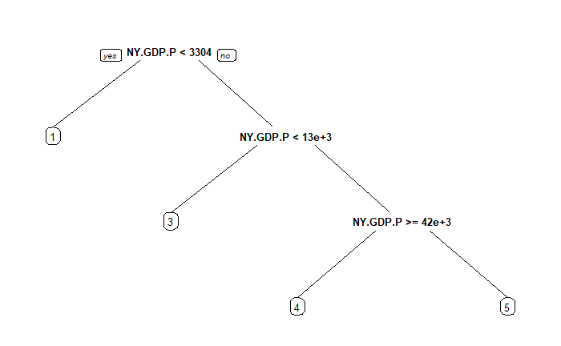

```r
tmp_dta <- diffs_mort_joined %>%
  filter(cause == "All causes") %>%
  mutate(quint_rel = cut(rel, breaks = quantile(rel, seq(0, 1, by = 0.2)), labels = F) %>% as.factor() ) %>%
  select(location,  year, cause, quint_rel, indicator_id, indicator_value) %>%
  spread(indicator_id, indicator_value)
mod_simple <- tmp_dta %>%
  rpart::rpart(quint_rel ~ year + NY.GDP.PCAP.PP.CD, data = ., method = "class")
# plot(model_01)
# text(model_01, cex = 0.8, use.n = T, xpd = T)
rpart.plot::prp(mod_simple, faclen = 0, cex = 0.8)
```

```
Cannot retrieve the model data (will ignore roundint=TRUE).
         To make this warning go away:
             Call prp with roundint=FALSE,
             or rebuild the rpart model with model=TRUE.
```

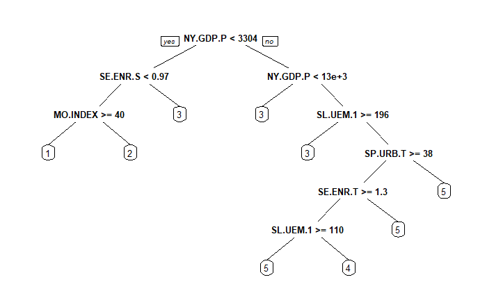

```r
mod_full <- tmp_dta %>%
  select(-location) %>%
  rpart::rpart(quint_rel ~ ., data = ., method = "class")
rpart.plot::prp(mod_full, faclen = 0, cex = 0.8)
```

| indicator_id | indicator |
| --- | --- |
| NY.GDP.PCAP.PP.CD | GDP per capita, PPP (current international $) |
| SE.ENR.SECO.FM.ZS | School enrollment, secondary (gross), gender parity index (GPI) |
| MO.INDEX.XQ | Overall Mo Ibrahim index |
| SL.UEM.1524.FM.ZS | Ratio of female to male youth unemployment rate (% ages 15-24) (modeled ILO estimate) |
| SP.URB.TOTL.MA.ZS | Urban population, male (% of total) |
| SE.ENR.TERT.FM.ZS | School enrollment, tertiary (gross), gender parity index (GPI) |

So, the above model seems to be suggesting:

- If GDP per cap < $3k, gender parity in 2ndry school enrolment is low, and Mo Ibrahim index high -> lowest/negative male gender disadvantage
- If GDP per cap < $3k, gender parity in 2ndry school enrolment is now, and Mo Ibrahim index low -> 2nd quintile
- If GDP per cap < $3k, gender parity in 2ndry school enrolment is high -> 3rd quintile
- If GDP per cap < $13k -> 3rd quintile
- If GDP per cap > $13k, high female:male youth unemployment rate -> 3rd quintile
- If GDP per cap > $13k, < 38% of males in urban areas (?) -> 5th quintile
- If GDP per cap > $13k, >= 38% of males in urban areas (?) but low gender parity index in tertiary school enrolment -> 5th quintile
- If GDP per cap > $13k, >= 38% of males in urban areas, high gender parity in tertiary school enrolment, but female:male youth unemployment >= 110 -> 5th quintile
- Otherwise 4th quintile